# ZhiLiu_HW1

Zhi Liu

August 28, 2016

### 1.2

1. nominal; b. ordinal; c. ordinal; d. nominal; e. nominal; f. ordinal.

### 1.4

1. When $\pi = 0.50$,

```r
dbinom(0, 2, 0.5) # Y = 0
```

```
## [1] 0.25
```

```r
dbinom(1, 2, 0.5) # Y = 1
```

```
## [1] 0.5
```

```r
dbinom(2, 2, 0.5) # Y = 2
```

```
## [1] 0.25
```

The mean of the binomial distribution is $n\pi = 2 * 0.5 = 1$. The standard deviation is $\sqrt{n\pi(1-\pi)} = \sqrt{2 * 0.5 * 0.5} = 0.7071068$.

1. When $\pi = 0.60$,

```r
dbinom(0, 2, 0.6) # Y = 0
```

```
## [1] 0.16
```

```r
dbinom(1, 2, 0.6) # Y = 1
```

```
## [1] 0.48
```

```r
dbinom(2, 2, 0.6) # Y = 2
```

```
## [1] 0.36
```

2. When $\pi = 0.40$,

```r
dbinom(0, 2, 0.4) # Y = 0
```

```
## [1] 0.36
```

```r
dbinom(1, 2, 0.4) # Y = 1
```

```
## [1] 0.48
```

```r
dbinom(2, 2, 0.4) # Y = 2
```

```
## [1] 0.16
```

$$L(\pi; y=1) = \binom{2}{1} \pi^{2-1} (1-\pi)^1 = 2\pi(1-\pi).$$

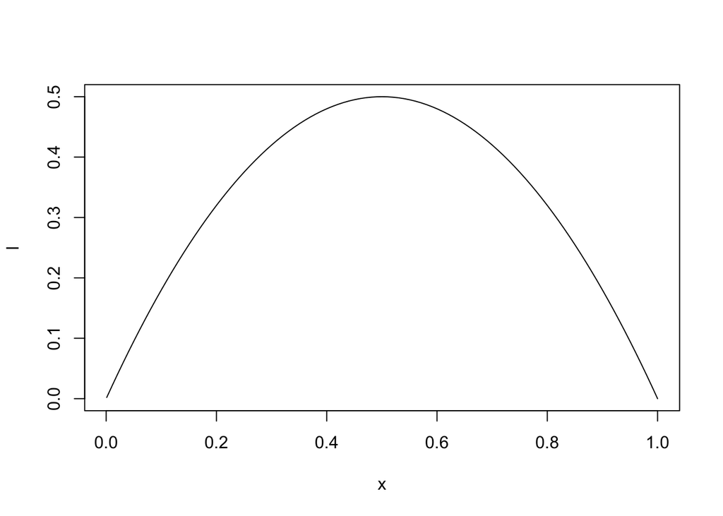

```r
l <- function(p) {
  2 * p * (1-p)
}
plot(l, c(0.001, 0.999))
```

### 1.6

1. $n_3 = n - n_1 - n_2$.

\begin{align} (n_1, n_2, n_3) & = (3, 0, 0) = (0, 3, 0) = (0, 0, 3) \\ & = (2, 1, 0) = (0, 2, 1) = (1, 0, 2) = (1, 2, 0) = (0, 1, 2) = (2, 0, 1) \\ & = (1, 1, 1) \end{align}

3. When $(\pi_1, \pi_2, \pi_3) = (0.25, 0.5, 0.25)$, and $(n_1, n_2, n_3) = (1, 2, 0)$,

```r
dmultinom(c(1, 2, 0), prob = c(0.25, 0.5, 0.25))
```

```
## [1] 0.1875
```

### 1.8

1. $\hat{p} = 344/1170 = 0.2940171$.
2. Do a proportion test, with $H_0: \pi = 0.5; H_1: \pi > 0$.

```r
prop.test(344, 1170, 0.5, conf.level = 0.99, alternative = "greater")
```

```
##
##  1-sample proportions test with continuity correction
##
## data:  344 out of 1170, null probability 0.5
## X-squared = 197.74, df = 1, p-value = 1
## alternative hypothesis: true p is greater than 0.5
## 99 percent confidence interval:
##  0.2636241 1.0000000
## sample estimates:
##         p
## 0.2940171
```

Can’t reject $H_0$.

Do the same test with $H_0: \pi = 0.5; H_1: \pi < 0$.

```r
prop.test(344, 1170, 0.5, conf.level = 0.99, alternative = "less")
```

```
##
##  1-sample proportions test with continuity correction
##
## data:  344 out of 1170, null probability 0.5
## X-squared = 197.74, df = 1, p-value < 2.2e-16
## alternative hypothesis: true p is less than 0.5
## 99 percent confidence interval:
##  0.000000 0.326333
## sample estimates:
##         p
## 0.2940171
```

Can reject $H_0$. Hence the minority would say “yes”.

3. This time estimate the two-sided interval with proportion test.

```r
prop.test(344, 1170, 0.5, conf.level = 0.99)
```

```
##
##  1-sample proportions test with continuity correction
##
## data:  344 out of 1170, null probability 0.5
## X-squared = 197.74, df = 1, p-value < 2.2e-16
## alternative hypothesis: true p is not equal to 0.5
## 99 percent confidence interval:
##  0.2605363 0.3298497
## sample estimates:
##         p
## 0.2940171
```